# Navigation

You are welcome to use this coding environment to train your agent for the project. Follow the instructions below to get started!

### 1. Start the Environment

Run the next code cell to install a few packages. This line will take a few minutes to run!

```python
!pip -q install ./python
```

```
tensorflow 1.7.1 has requirement numpy>=1.13.3, but you'll have numpy 1.12.1 which is incompatible.
ipython 6.5.0 has requirement prompt-toolkit<2.0.0,>=1.0.15, but you'll have prompt-toolkit 2.0.10 which is incompatible.
```

The environment is already saved in the Workspace and can be accessed at the file path provided below. Please run the next code cell without making any changes.

```python
from unityagents import UnityEnvironment
import numpy as np

# please do not modify the line below
env = UnityEnvironment(file_name="/data/Banana_Linux_NoVis/Banana.x86_64")
```

```
INFO:unityagents:
'Academy' started successfully!
Unity Academy name: Academy
        Number of Brains: 1
        Number of External Brains : 1
        Lesson number : 0
        Reset Parameters :

Unity brain name: BananaBrain
        Number of Visual Observations (per agent): 0
        Vector Observation space type: continuous
        Vector Observation space size (per agent): 37
        Number of stacked Vector Observation: 1
        Vector Action space type: discrete
        Vector Action space size (per agent): 4
        Vector Action descriptions: , , ,
```

Environments contain *brains* which are responsible for deciding the actions of their associated agents. Here we check for the first brain available, and set it as the default brain we will be controlling from Python.

```python
# get the default brain
brain_name = env.brain_names[0]
brain = env.brains[brain_name]
```

### 2. Examine the State and Action Spaces

Run the code cell below to print some information about the environment.

```python
# reset the environment
env_info = env.reset(train_mode=True)[brain_name]

# number of agents in the environment
print('Number of agents:', len(env_info.agents))

# number of actions
action_size = brain.vector_action_space_size
print('Number of actions:', action_size)

# examine the state space
state = env_info.vector_observations[0]
print('States look like:\n', state)
state_size = len(state)
print('States have length:', state_size)
```

```
Number of agents: 1
Number of actions: 4
States look like:
 [ 1.          0.          0.          0.          0.84408134  0.          0.
  1.          0.          0.0748472   0.          1.          0.          0.
  0.25755     1.          0.          0.          0.          0.74177343
  0.          1.          0.          0.          0.25854847  0.          0.
  1.          0.          0.09355672  0.          1.          0.          0.
  0.31969345  0.          0.        ]
States have length: 37
```

### 3. Take Random Actions in the Environment

In the next code cell, you will learn how to use the Python API to control the agent and receive feedback from the environment.

Note that **in this coding environment, you will not be able to watch the agent while it is training**, and you should set `train_mode=True` to restart the environment.

```python
env_info = env.reset(train_mode=True)[brain_name] # reset the environment
state = env_info.vector_observations[0]            # get the current state
score = 0                                          # initialize the score
while True:
    action = np.random.randint(action_size)        # select an action
    env_info = env.step(action)[brain_name]        # send the action to the environment
    next_state = env_info.vector_observations[0]   # get the next state
    reward = env_info.rewards[0]                   # get the reward
    done = env_info.local_done[0]                  # see if episode has finished
    score += reward                                # update the score
    state = next_state                             # roll over the state to next time step
    if done:                                       # exit loop if episode finished
        break

print("Score: {}".format(score))
```

```
Score: 0.0
```

When finished, you can close the environment.

```python
#env.close()
```

### 4. It's Your Turn!

Now it's your turn to train your own agent to solve the environment! A few **important notes**:

- When training the environment, set `train_mode=True`, so that the line for resetting the environment looks like the following:

  ```
  env_info = env.reset(train_mode=True)[brain_name]
  ```

- To structure your work, you're welcome to work directly in this Jupyter notebook, or you might like to start over with a new file! You can see the list of files in the workspace by clicking on *Jupyter* in the top left corner of the notebook.
- In this coding environment, you will not be able to watch the agent while it is training. However, *after training the agent*, you can download the saved model weights to watch the agent on your own machine!

### 5. Submission

> NOTE: Following code is heavily based on `Lunar Lander` exercise from class.

Import all necessary libraries, and especially import the classes `Agent` and `QNetwork`, which contain the main parts of code for the DQN algorithm implementation.

```python
import random
import torch
import numpy as np
import matplotlib.pyplot as plt
from collections import deque
import pickle

# Use the 2 files dqn_agent.py and model.py
from dqn_agent import Agent
```

#### Deep Q-Network algorithm

The Deep Q-Learning (DQN) algorithm is a technique to learn the action value function $Q(s,a)$. It is basically an online version of a neural fitted-value iteration [paper](https://link.springer.com/chapter/10.1007/11564096_32) of 2005 (Riedmiller): Training of a Q-value function represented by a Multi-Layered Perceptron. In sloppy terms, this function can be referred to as the *Cheat Sheet Q*, which tells the agent which action $a$ will yield the highest reward $R$ in a given situation $s$.

In *Q-Learning* (which is the pioneer technique for DQN) the $Q$-table is supposed to provide actions for the whole state space $S$ and action space $A$, i.e. it will ultimately know the value of each possible action in each possible situation. This can easily become too large in terms of memory and computational requirements. This is where *Deep Q-Learning* comes in: Instead of trying to learn the complete $Q$-table, a deep network is used to approximate $Q(s,a)$.

The useful additions of the Deep Q-Network compared to plain Q-Learning algorithm are:

- Use of rolling history of past data: *Experience Replay*
- Use of a target network to represent the old Q-Function, which is used to calculate the loss of every action during training: *Fixed Q-Targets*

This helps smoothing out the behaviors, avoiding oscillations, and prevents the value estimates to get out of control. Overall, this allows RL-agents to converge more reliably during training.

The algorithm can be sketched out with following steps:

1. *Initialization* of Replay memory $D$, Action value function $\hat{q}$ and Target action-value weights $\vec{w}^{-} \leftarrow \, \vec{w}$
2. *Sample* an action using an $\epsilon$-greedy policy, observe reward and next state, and store the new experience tuple in replay memory
3. *Learn* (i.e. update the weights) periodically after several experiences (minibatches), not after every new experience
4. Repeat 2. and 3. for number of episodes

#### Agent

The class `Agent` is taken from class exercise code. It provides necessary methods to interact with the environment, following the Deep Q-Learning algorithm with Fixed Q-Targets and Experience Replay extensions (as discussed in class).

The class most importantly holds a `ReplayBuffer` with 1000 entries to store experience tuples, that also supports random sampling, and two `QNetwork`s, in order to decouple targets from network parameters.

Further algorithm parameters are:

- Minibatch size: `64`
- Discount factor (gamma): `0.99`
- Softy update factor of target parameters (tau): `0.003`
- Learning rate (alpha): `0.0005`
- Network update every 4 steps

#### Model

The class `QNetwork` implements the model, using PyTorch. 3 fully connected layers map the 37 inputs onto 64 hidden, another 64 hidden, and finally 4 output units. The state vector is thereby mapped onto action values for all available agent actions. ReLU activation functions are used on the first two layers.

```python
def dqn(n_episodes=2000, max_t=1000, eps_start=1.0, eps_end=0.01, eps_decay=0.995, stop_score=13.0):
    """Deep Q-Learning.

    Params
    ======
        n_episodes (int): maximum number of training episodes
        max_t (int): maximum number of timesteps per episode
        eps_start (float): starting value of epsilon, for epsilon-greedy action selection
        eps_end (float): minimum value of epsilon
        eps_decay (float): multiplicative factor (per episode) for decreasing epsilon
    """
    scores = []                        # list containing scores from each episode
    scores_window = deque(maxlen=100)  # last 100 scores
    eps = eps_start                    # initialize epsilon

    for i_episode in range(1, n_episodes+1):
        #state = env.reset()
        env_info = env.reset(train_mode=True)[brain_name] # reset the environment
        state = env_info.vector_observations[0]           # get the current state

        score = 0

        for t in range(max_t):
            action = agent.act(state, eps)

            #next_state, reward, done, _ = env.step(action)
            env_info = env.step(action)[brain_name]        # send the action to the environment
            next_state = env_info.vector_observations[0]   # get the next state
            reward = env_info.rewards[0]                   # get the reward
            done = env_info.local_done[0]                  # see if episode has finished

            agent.step(state, action, reward, next_state, done)
            state = next_state
            score += reward

            if done:
                break

        scores_window.append(score)       # save most recent score
        scores.append(score)              # save most recent score
        eps = max(eps_end, eps_decay*eps) # decrease epsilon

        print('\rEpisode {}\tAverage Score: {:.2f}'.format(i_episode, np.mean(scores_window)), end="")
        if i_episode % 100 == 0:
            print('\rEpisode {}\tAverage Score: {:.2f}'.format(i_episode, np.mean(scores_window)))
        if np.mean(scores_window)>=stop_score:
            print('\nEnvironment solved in {:d} episodes!\tAverage Score: {:.2f}'.format(i_episode-100, np.mean(scores_window)))

            torch.save(agent.qnetwork_local.state_dict(), 'model.pt')
            with open('scores.pkl', 'wb') as f:
                pickle.dump(scores, f)

            break

    return scores
```

```python
agent = Agent(state_size=state_size, action_size=action_size, seed=0)
%time scores = dqn()
```

```
Episode 100	Average Score: 1.03
Episode 200	Average Score: 3.72
Episode 300	Average Score: 7.43
Episode 400	Average Score: 10.67
Episode 500	Average Score: 12.56
Episode 564	Average Score: 13.03
Environment solved in 464 episodes!	Average Score: 13.03
CPU times: user 4min 4s, sys: 20.5 s, total: 4min 25s
Wall time: 6min 18s
```

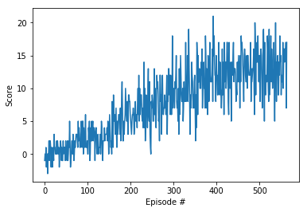

```python
# plot the scores
fig = plt.figure()
ax = fig.add_subplot(111)
plt.plot(np.arange(len(scores)), scores)
plt.ylabel('Score')
plt.xlabel('Episode #')
plt.show()

# with open('scores.pkl', 'rb') as f:
#     scores_from_file = pickle.load(f)
```

```python
agent = Agent(state_size=state_size, action_size=action_size, seed=0)
%time scores = dqn(stop_score=20.)
```

```
Episode 100	Average Score: 0.75
Episode 200	Average Score: 3.12
Episode 300	Average Score: 6.96
Episode 400	Average Score: 9.73
Episode 500	Average Score: 11.96
Episode 600	Average Score: 11.88
Episode 700	Average Score: 13.37
Episode 800	Average Score: 15.31
Episode 900	Average Score: 14.19
Episode 1000	Average Score: 13.61
Episode 1100	Average Score: 13.52
Episode 1200	Average Score: 13.80
Episode 1300	Average Score: 14.84
Episode 1400	Average Score: 13.48
Episode 1500	Average Score: 14.80
Episode 1600	Average Score: 14.45
Episode 1700	Average Score: 14.84
Episode 1800	Average Score: 13.69
Episode 1900	Average Score: 14.23
Episode 2000	Average Score: 15.94
CPU times: user 14min 53s, sys: 1min 14s, total: 16min 8s
Wall time: 23min 2s
```

```python
env.close()
```

#### Future work

The current algorithm achieves satisfactory scores of +13 after less than 500 learning episodes. It achieves almost +16 after 2000 episodes. Nevertheless, with further improvements the algorithm might perform even better.

Possible ideas for future work are:

- Investigate the model architecture in more depth, find a more optimal neural network.
- Use an hyperparameter optimization library such as `Scikit-Optimize` or `Optuna`, in order to figure out the optimal hyperparameters for learning.
- Use different optimizations described in the DQN literature, e.g.:
  - Prioritized Experience Replay
  - Distributional DQN
  - Noisy DQN